# MSc Statistical overview

# Housekeeping

### Preamble

By Katherine Duchesneau

We are working with the roots Lesion and Mycorrhiza dataset for now.

### R details

This section contains all the necessary details about the R version and package version used to run this Notebook.

- File creation date: 2018-01-28
- R version 3.3.2 (2016-10-31)
- `tidyverse` package version: 1.2.1
- `lme4` package version 1.1.15
- `MASS` package version 7.3.48
- `MuMIn` package version 1.40.0
- `emmeans` package version 1.1
- `boot` package version 1.3.18
- `brms` package version 2.1.0
- `loo` package version 1.1.0
- `fitdistrplus` package version 1.0.9
- `mefa` package version 3.2.7
- `library(devtools)` and `install_github("vqv/ggbiplot")` package version 0.55
- also requires [rtools](https://cran.r-project.org/bin/windows/Rtools/)

### Load Packages and Functions

```r
library(tidyverse)
library(lme4)
library(MASS)
library(MuMIn)
library(emmeans)
library(boot)
library(brms)
library(loo)
library(fitdistrplus)
library(mefa)
library(ggbiplot)
```

## KAT, PLEASE BREAK UP YOUR CODE INTO SMALL CHUNCKS AND EXPLAIN WHAT EACH IS DOING.

Load a custome theme for clean, readable graphs

## EXPLAIN WHAT THIS OVERDISPERSION FUNCTION IS FOR…

# Introducing the Data

### Load/ Modify data: Co-occurence

```r
mdata <- read.csv("Assessing_Oct_20.csv",stringsAsFactors=F)
indiv <- mdata$CODE[!mdata$CODE==""]
tdata <- mdata[grep("[0-9]+",mdata$Cross),]
nrow(tdata)/length(indiv)
```

```
[1] 99.55752
```

```r
# This is not the same because some individuals just had the totals not the cooccurence data
## THE COMMENT IS NOT CLEAR, EXPLAIN...
indiv2 <- tdata$CODE[!tdata$CODE==""]
nrow(tdata)/length(indiv2)
```

```
[1] 100
```

```r
indiv2 <- data.frame(indiv2)
indiv2 <- mefa:::rep.data.frame(indiv2,each=100)
fdata <- cbind(indiv2,tdata)
fdata <- fdata[,-c(2,3,4,9,14,17,18)]
# Cleaning up the occurence data
## CLEANING UP HOW?
fdata[is.na(fdata)] <- 0
fdata$Lesion<-rowSums(fdata[,2:4])
fdata[fdata$Lesion>1,]
```

| indiv2 | Decay | Pathogen | Hyphae | None.Path | Arbuscules | Vesicles | M_Hyphae | None.Myc | Herbivory | None.Herb | Lesion |
| --- | --- | --- | --- | --- | --- | --- | --- | --- | --- | --- | --- |

```r
fdata$Mycorrhiza<-rowSums(fdata[,6:8])
fdata[fdata$Mycorrhiza>1,]
```

| indiv2 | Decay | Pathogen | Hyphae | None.Path | Arbuscules | Vesicles | M_Hyphae | None.Myc | Herbivory | None.Herb | Lesion | Mycorrhiza |
| --- | --- | --- | --- | --- | --- | --- | --- | --- | --- | --- | --- | --- |

```r
fdata <- fdata[,-c(2:4,6:8)]
#### Checking data for problems ####
summary(fdata)
```

```
     indiv2       None.Path           None.Myc           Herbivory
 10IAH1 :  100   Length:22500       Length:22500       Min.   :0.00000
 10IAH2 :  100   Class :character   Class :character   1st Qu.:0.00000
 10ISC1 :  100   Mode  :character   Mode  :character   Median :0.00000
 10ISC2 :  100                                         Mean   :0.03658
 10ISC3 :  100                                         3rd Qu.:0.00000
 10OAH1 :  100                                         Max.   :1.00000
 (Other):21900
   None.Herb          Lesion        Mycorrhiza
 Min.   :0.0000   Min.   :0.000   Min.   :0.0000
 1st Qu.:1.0000   1st Qu.:0.000   1st Qu.:0.0000
 Median :1.0000   Median :1.000   Median :1.0000
 Mean   :0.9631   Mean   :0.622   Mean   :0.5732
 3rd Qu.:1.0000   3rd Qu.:1.000   3rd Qu.:1.0000
 Max.   :1.0000   Max.   :1.000   Max.   :1.0000
```

```r
fdata$None.Path <- as.integer(fdata$None.Path)
fdata$None.Myc <- as.integer(fdata$None.Myc)
fdata[is.na(fdata)] <- 0
sherb <- fdata$Herbivory+fdata$None.Herb
fdata[sherb!=1,]
```

|  | indiv2 | None.Path | None.Myc | Herbivory | None.Herb | Lesion | Mycorrhiza |
| --- | --- | --- | --- | --- | --- | --- | --- |
| 1573 | 7ISC1 | 0 | 0 | 0 | 0 | 1 | 1 |
| 1587 | 7ISC1 | 0 | 0 | 0 | 0 | 1 | 1 |
| 1729 | 7ISC2 | 1 | 0 | 0 | 0 | 0 | 1 |
| 9107 | 5OSC2 | 1 | 1 | 0 | 0 | 0 | 0 |
| 9154 | 3ISC3 | 1 | 1 | 0 | 0 | 0 | 0 |
| 14441 | 5OAH1 | 0 | 0 | 0 | 0 | 1 | 1 |
| 23150 | 7OCL1 | 0 | 1 | 0 | 0 | 1 | 0 |
| 23253 | 3OMR2 | 1 | 1 | 0 | 0 | 0 | 0 |

```r
fdata[sherb!=1,"None.Herb"]<-1
# Are all the sums equal to 100 for herb?
dframeHerb <- data.frame(counter=NA, Indiv2=NA,Sum=NA)
c <- 1
for (i in unique(fdata$indiv2)){
  dframeHerb[c,] <- NA
  subdata <- fdata[fdata$indiv2==i,]
  dframeHerb$counter[c] <- c
  dframeHerb$Indiv2[c] <- i
  dframeHerb$Sum[c] <- sum(subdata[,"Herbivory"]+subdata[,"None.Herb"])
  subdata <- NA
  c <- c + 1
}
dframeHerb[dframeHerb$Sum!=100,]
```

| counter | Indiv2 | Sum |
| --- | --- | --- |

```r
# Are all the sums equal to 100 for Mycorrhiza?
dframeMyc <- data.frame(counter=NA, Indiv2=NA,Sum=NA)
c <- 1
for (i in unique(fdata$indiv2)){
  dframeMyc[c,] <- NA
  subdata <- fdata[fdata$indiv2==i,]
  dframeMyc$counter[c] <- c
  dframeMyc$Indiv2[c] <- i
  dframeMyc$Sum[c] <- sum(subdata[,"Mycorrhiza"]+subdata[,"None.Myc"])
  subdata <- NA
  c <- c + 1
}
dframeMyc[dframeMyc$Sum!=100,]
```

| counter | Indiv2 | Sum |
| --- | --- | --- |

```r
# Are all the sums equal to 100 for Lesions?
dframeLesion <- data.frame(counter=NA, Indiv2=NA,Sum=NA)
c <- 1
for (i in unique(fdata$indiv2)){
  dframeLesion[c,] <- NA
  subdata <- fdata[fdata$indiv2==i,]
  dframeLesion$counter[c] <- c
  dframeLesion$Indiv2[c] <- i
  dframeLesion$Sum[c] <- sum(subdata[,"Lesion"]+subdata[,"None.Path"])
  subdata <- NA
  c <- c + 1
}
dframeLesion[dframeLesion$Sum!=100,]
```

| counter | Indiv2 | Sum |
| --- | --- | --- |

```r
# Separating "Individual" into: pop,location,species columns
fdata$pop <- gsub("^([0-9]+)[I,O][A-Z]+.*","\\1",fdata$indiv)
fdata$location <- gsub("^[0-9]+([I,O])[A-Z]+.*","\\1",fdata$indiv)
fdata$species <- sub("^[0-9]+[I,O]([A-Z]+).*","\\1",fdata$indiv)
fdata$location <- as.factor(fdata$location)
fdata$species <- as.factor(fdata$species)
fdata$pop <- as.factor(fdata$pop)
fdata$indiv2 <- as.character(fdata$indiv2)
summary(fdata)
```

```
    indiv2            None.Path        None.Myc        Herbivory
 Length:22500       Min.   :0.000   Min.   :0.0000   Min.   :0.00000
 Class :character   1st Qu.:0.000   1st Qu.:0.0000   1st Qu.:0.00000
 Mode  :character   Median :0.000   Median :0.0000   Median :0.00000
                    Mean   :0.378   Mean   :0.4268   Mean   :0.03658
                    3rd Qu.:1.000   3rd Qu.:1.0000   3rd Qu.:0.00000
                    Max.   :1.000   Max.   :1.0000   Max.   :1.00000

   None.Herb          Lesion        Mycorrhiza          pop       location  species
 Min.   :0.0000   Min.   :0.000   Min.   :0.0000   5      :2900   I:10600   AH:3100
 1st Qu.:1.0000   1st Qu.:0.000   1st Qu.:0.0000   7      :2600   O:11900   CL:3900
 Median :1.0000   Median :1.000   Median :1.0000   8      :2600             GA:4900
 Mean   :0.9634   Mean   :0.622   Mean   :0.5732   3      :2200             GR:1300
 3rd Qu.:1.0000   3rd Qu.:1.000   3rd Qu.:1.0000   4      :2200             MR:3100
 Max.   :1.0000   Max.   :1.000   Max.   :1.0000   1      :2000             SC:6200
                                                   (Other):8000
```

```r
fdata %>% drop_na()->fdata
fdata$None.Myc <- as.factor(fdata$None.Myc)
fdata$Herbivory <- as.factor(fdata$Herbivory)
fdata$Mycorrhiza <- as.factor(fdata$Mycorrhiza)
fdata$Lesion <- as.factor(fdata$Lesion)
fdata$None.Herb <- as.factor(fdata$None.Herb)
fdata$None.Path <- as.factor(fdata$None.Path)
summary(fdata)
```

```
    indiv2          None.Path None.Myc  Herbivory None.Herb Lesion    Mycorrhiza
 Length:22500       0:13995   0:12897   0:21677   0:  823   0: 8505   0: 9603
 Class :character   1: 8505   1: 9603   1:  823   1:21677   1:13995   1:12897
 Mode  :character




      pop       location  species
 5      :2900   I:10600   AH:3100
 7      :2600   O:11900   CL:3900
 8      :2600             GA:4900
 3      :2200             GR:1300
 4      :2200             MR:3100
 1      :2000             SC:6200
 (Other):8000
```

```r
#### Gather ####
length(unique(fdata$indiv2))
```

```
[1] 225
```

```r
Cross<- data.frame(c(rep(1:100, times=225)))
fdatac <- cbind(fdata,Cross)
colnames(fdatac)[11]<-"cross"
fdatac %>% gather(Trait, Value, c(4,6,7)) -> fdata_gather # The warning is an inconsequential bug from tidyverse (https://github.com/tidyverse/tidyr/issues/386)
fdata_gather$Value<-as.numeric(fdata_gather$Value)
fdata_gather$Trait<-as.factor(fdata_gather$Trait)
fdata_gather <- fdata_gather[,-c(2:4)]
```

### Load/ Modify data: Totals

```r
mdata<-read.csv("Assessing_Oct_20.csv",stringsAsFactors=F)
indiv<-mdata$CODE[!mdata$CODE==""]
tdata<-mdata[mdata$Slide=="TOTAL",]
length(indiv)
```

```
[1] 226
```

```r
nrow(tdata)
```

```
[1] 226
```

```r
ndata<-cbind(indiv,tdata)
ndata<-ndata[,-c(2,3,4,9,14,17:37)]
ndata$None.Path<-as.integer(ndata$None.Path)
ndata$None.Myc<-as.integer(ndata$None.Myc)
# Checking data for problems
problemsPath<-ndata[!rowSums(ndata[,c(2:5)])==100,]
problemsHyph<-ndata[!rowSums(ndata[,c(6:9)])==100,]
problemsHerb<-ndata[!rowSums(ndata[,c(10:11)])==100,]
# Separating "Individual" into: pop,location,species columns
ndata$pop<-gsub("^([0-9]+)[I,O][A-Z]+.*","\\1",ndata$indiv)
ndata$location<-gsub("^[0-9]+([I,O])[A-Z]+.*","\\1",ndata$indiv)
ndata$species<-gsub("^[0-9]+[I,O]([A-Z]+).*","\\1",ndata$indiv)
ndata$location<-as.factor(ndata$location)
ndata$species<-as.factor(ndata$species)
ndata$pop<-as.factor(ndata$pop)
#### Totalling the scores####
binlesion<-cbind(ndata$None.Path,100-ndata$None.Path)
binmycorr<-cbind(ndata$None.Myc,100-ndata$None.Myc)
binherbivory<-cbind(ndata$None.Herb,100-ndata$None.Herb)
summary(ndata)
```

```
     indiv         Decay           Pathogen          Hyphae        None.Path
 10IAH1 :  1   Min.   : 0.000   Min.   : 0.000   Min.   : 2.00   Min.   : 0.00
 10IAH2 :  1   1st Qu.: 1.000   1st Qu.: 2.000   1st Qu.:34.00   1st Qu.:20.00
 10ISC1 :  1   Median : 4.000   Median : 4.000   Median :48.00   Median :33.00
 10ISC2 :  1   Mean   : 7.894   Mean   : 7.168   Mean   :47.23   Mean   :37.71
 10ISC3 :  1   3rd Qu.: 9.000   3rd Qu.:10.000   3rd Qu.:63.00   3rd Qu.:53.75
 10OAH1 :  1   Max.   :60.000   Max.   :86.000   Max.   :96.00   Max.   :97.00
 (Other):220
   Arbuscules        Vesicles         M_Hyphae        None.Myc        Herbivory
 Min.   : 0.000   Min.   : 0.000   Min.   : 0.00   Min.   :  0.00   Min.   : 0.000
 1st Qu.: 0.000   1st Qu.: 1.000   1st Qu.:30.25   1st Qu.: 18.00   1st Qu.: 0.000
 Median : 0.000   Median : 6.000   Median :46.00   Median : 38.50   Median : 1.000
 Mean   : 2.363   Mean   : 9.956   Mean   :45.16   Mean   : 42.52   Mean   : 3.624
 3rd Qu.: 3.000   3rd Qu.:14.000   3rd Qu.:61.00   3rd Qu.: 66.00   3rd Qu.: 4.000
 Max.   :21.000   Max.   :73.000   Max.   :94.00   Max.   :100.00   Max.   :38.000

   None.Herb           pop     location species
 Min.   : 62.00   5      :29   I:106    AH:31
 1st Qu.: 96.00   8      :27   O:120    CL:39
 Median : 99.00   7      :26            GA:50
 Mean   : 96.38   3      :22            GR:13
 3rd Qu.:100.00   4      :22            MR:31
 Max.   :100.00   1      :20            SC:62
                  (Other):80
```

```r
# scale data (only need to scale the numerical variables!)
numcols <- grep("^None.",names(ndata))
ndatas <- ndata
ndatas[,numcols] <- scale(ndatas[,numcols])
```

### Variable descriptions

The variables are:

Co-occurence:

- **indiv2:** The unique code given to a sample. In this dataset the unique sample code repeats 100 times for each cross where an observation was taken on the root sample.
- **None.Path:** A binary representation of whether a sign of pathogen activity was recorded (0) or not (1).
- **Lesion:** The counterpart to the previous variable (None.Path). A binary representation of whether a sign of pathogen activity was recorded (1) or not (0).
- **None.Myc:** A binary representation of whether a sign of myccorhizal activity was recorded (0) or not (1).
- **Mycorrhiza:** The counterpart to the previous variable (None.Myc). A binary representation of whether a sign of mycorrhizal activity was recorded (1) or not (0).
- **None.Herb:** A binary representation of whether herbivory was recorded (0) or not (1).
- **Herbivory:** The counterpart to the previous variable (None.Herb). A binary representation of whether Herbivoryn was recorded (1) or not (0).
- **Population (pop):** The coding number representing the population at which the sample was collected.
- **location:** A code representing the whether the sample was collected inside a Alliaria petiolata population (I) or whther it was collected at least 7 m outside of he furthest individual in the A. petiolata population (O).
- **species:** The particular species to which the sample belongs.
- **Cross:** The particular cross number where the data was recorded on the individual sample.

Total scores:

- **indiv:** The unique code given to a sample.
- **Decay:** The total number of crosses where decay was recorded an individual sample when doing a total of 100 crosses/ sample.
- **Pathogen:** The total number of crosses where pathogen was recorded on an individual sample when doing a total of 100 crosses/ sample.
- **Hyphae:** The total number of crosses where non-myccorhizal hyphae was recorded on an individual sample when doing a total of 100 crosses/ sample.
- **None.Path:** The total number of crosses where no signs of pathogen activities were recorded on an individual sample when doing a total of 100 crosses/ sample. Note that the total of Decay, Pathogen, Hyphae, and None.Path must come to 100 per individual to account for all 100 crosses.
- **Arbuscule:** The total number of crosses where an arbuscule was recorded on an individual sample when doing a total of 100 crosses/ sample.
- **Vesicules:** The total number of crosses where a vesicule was recorded on an individual sample when doing a total of 100 crosses/ sample.
- **M_Hyphae:** The total number of crosses where myccorhizal hyphae was recorded on an individual sample when doing a total of 100 crosses/ sample.
- **None.Myc:** The total number of crosses where no signs of mycorrhizal activities were recorded on an individual sample when doing a total of 100 crosses/ sample. Note that the total of Arbuscules, Vesicules, M_Hyphae, and None.Myc must come to 100 per individual to account for all 100 crosses.
- **Herbivory:** The total number of crosses where herbivory was recorded on an individual sample when doing a total of 100 crosses/ sample.
- **None.Herb:** The total number of crosses where no signs of herbivory was recorded on an individual sample when doing a total of 100 crosses/ sample. Note that the total of Herbivory, and None.Herb must come to 100 per individual to account for all 100 crosses.
- **Population (pop):** The coding number representing the population at which the sample was collected.
- **location:** A code representing the whether the sample was collected inside a Alliaria petiolata population (I) or whther it was collected at least 7 m outside of he furthest individual in the A. petiolata population (O).
- **species:** The particular species to which the sample belongs.

# Reviewing of hypotheses:

## Question 1: Is there evidence that Mycorrhizal colonization provides protection against root pathogen damage?

## Question 2: Do these effects vary among species?

### Hypothesis 1

### VERY NICE PREDICTION FIGURES! PERSONALLY, I WOULD MAKE THE DOTS BIGGER AND BIVARIATE NORMAL (SEE CHANGES):

Mycorrhizal colonization protects roots from lesions and herbivory.

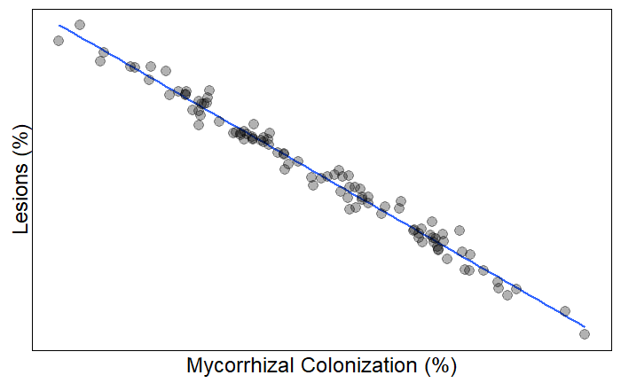

### Hypothesis 2

A. petiolata invasion reduces mycorrhizal colonization and increases pathogen colonization and herbivory

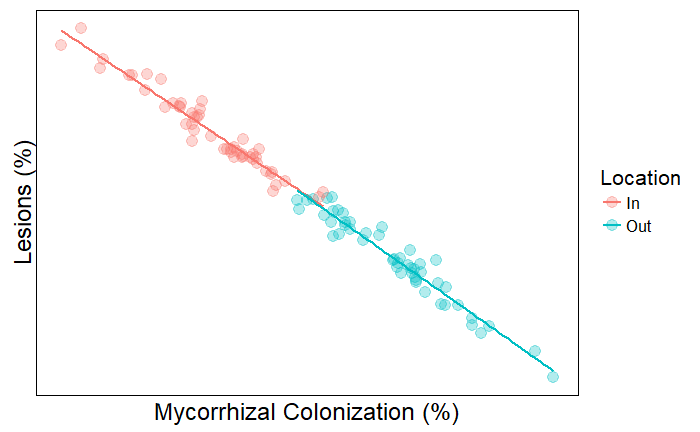

### Hypothesis 3

Cycorrhizal colonization is reduced in the presence of A. petiolata

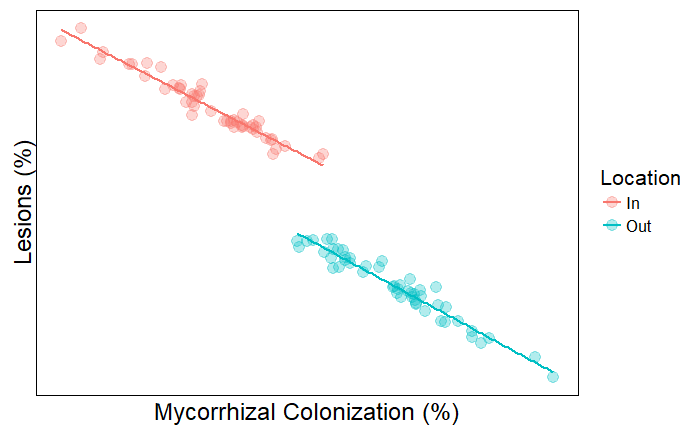

### Hypothesis 4

Mycorrhizal protection is completely lost in the presence of A. petiolata

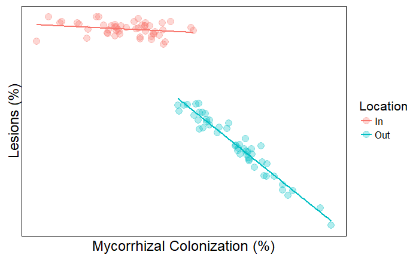

## Molecular data Hypothesis

### Hypothesis 1

A. petiolata invasion changes the diversity of mycorrhizal and other fungal species present in the soil.

I will find that the molecular data from the soil extraction supports this claim by having a reduced biodiversity and abundance of mycorrhiza in samples taken inside A. petiolata populations.

## IMPORTANT: BEFORE RUNNING COMPLICATED MODELS: (1) TAKE A LOOK AT THE DATA, (2) RUN SIMPLE MODELS – SEE IF IT IS EVEN WORTH YOUR TIME & EFFORT

### Hypothesis 2

There will be a negative correlation between mycorrhizal and fungal pathogen diversity.

# Histology data Analysis

### Data exploration:

Calculate plant-level Mycchorizae, pathogens and herbivory:

```r
# Fix column characteristics for plotting and analysis
fdata$indiv2<-as.factor(fdata$indiv2)
fdata$Mycorrhiza<-as.numeric(paste(fdata$Mycorrhiza))
fdata$Lesion<-as.numeric(paste(fdata$Lesion))
fdata$Herbivory<-as.numeric(paste(fdata$Herbivory))
pct<-function(x){
  sum(x)/100
}
# Calculate plant-level averages
fdat_ind<-aggregate(fdata[,c("Mycorrhiza","Lesion","Herbivory")],
                    by=list(indiv2=fdata$indiv2,pop=fdata$pop,loc=fdata$loc,species=fdata$species),
                    pct)
```

## SIMPLE LINEAR MODEL AND VISUALIZATION:

### Mycorrhia model results

1. Mycorrhiza colonization is significantly higher outside patches of A. petiolata than inside 2a. Species vary in Mycorrhiza colonization, with highest colonization in SC and others relatively similar. 2b. Effect of A. petiolata on Mycorrhiza colonization differs among species, with more pronounced effects for GR and MR, and will little effect for GA
2. Effect of A. petiolata on Mycorrhiza colonization varies by population, but not as strongly as among species

```r
## Mycorrhiza model (NOTE: No loc*species because not all species present in all populations)
base.Myc<-lmer(Mycorrhiza~species+loc+species:loc+(1|pop)+(1|pop:loc),data=fdat_ind)
noint.Myc<-lmer(Mycorrhiza~species+loc+(1|pop)+(1|pop:loc),data=fdat_ind)
anova(base.Myc,noint.Myc)
```

```
refitting model(s) with ML (instead of REML)
```

```
Data: fdat_ind
Models:
noint.Myc: Mycorrhiza ~ species + loc + (1 | pop) + (1 | pop:loc)
base.Myc: Mycorrhiza ~ species + loc + species:loc + (1 | pop) + (1 | pop:loc)
          Df     AIC   BIC logLik deviance  Chisq Chi Df Pr(>Chisq)
noint.Myc 10 -17.641 16.52 18.821  -37.641
base.Myc  15 -30.102 21.14 30.051  -60.102 22.461      5  0.0004279 ***
---
Signif. codes:  0 ‘***’ 0.001 ‘**’ 0.01 ‘*’ 0.05 ‘.’ 0.1 ‘ ’ 1
```

```r
base.Myc ## Inspect coefficients
```

```
Linear mixed model fit by REML ['lmerMod']
Formula: Mycorrhiza ~ species + loc + species:loc + (1 | pop) + (1 | pop:loc)
   Data: fdat_ind
REML criterion at convergence: -12.5748
Random effects:
 Groups   Name        Std.Dev.
 pop:loc  (Intercept) 0.06622
 pop      (Intercept) 0.00000
 Residual             0.21042
Number of obs: 225, groups:  pop:loc, 22; pop, 11
Fixed Effects:
   (Intercept)       speciesCL       speciesGA       speciesGR       speciesMR       speciesSC
       0.38985        -0.05067         0.03105         0.01338        -0.02840         0.28780
          locO  speciesCL:locO  speciesGA:locO  speciesGR:locO  speciesMR:locO  speciesSC:locO
       0.15278         0.13277        -0.10069         0.23077         0.28893        -0.04707
```

```r
anova(base.Myc)
```

```
Analysis of Variance Table
            Df  Sum Sq Mean Sq F value
species      5 3.05633 0.61127 13.8058
loc          1 0.97496 0.97496 22.0201
species:loc  5 0.98748 0.19750  4.4606
```

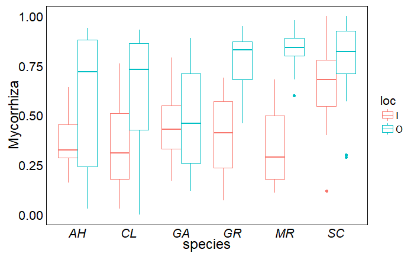

```r
ggplot(fdat_ind,aes(species,Mycorrhiza,colour=loc))+geom_boxplot()+theme_simple()
```

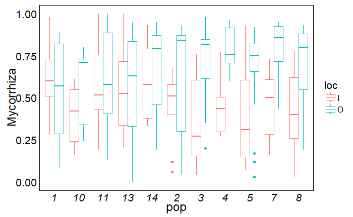

```r
ggplot(fdat_ind,aes(pop,Mycorrhiza,colour=loc))+geom_boxplot()+theme_simple()
```

### Lesions model results

```r
anova(norint.Les,Les2)
```

```
refitting model(s) with ML (instead of REML)
```

```
Data: fdat_ind
Models:
Les2: Lesion ~ Mycorrhiza * species * loc - Mycorrhiza:species:loc +
Les2:     (1 | pop)
norint.Les: Lesion ~ Mycorrhiza * species * loc + (1 | pop)
           Df     AIC      BIC logLik deviance  Chisq Chi Df Pr(>Chisq)
Les2       21 -86.188 -14.4502 64.094  -128.19
norint.Les 26 -83.427   5.3917 67.713  -135.43 7.2386      5     0.2035
```

## Hypothesis 1: Lesion ~ Mycorriza

### GIVEN THE NEW ANALYSIS ABOVE, THIS ISN’T WORTHWILE BECAUSE THERE IS NO SIGNIFICANT Myc:species:loc

```r
# calculating the r
indivCODE <- unique(fdata$indiv2)
dfcorr <-data.frame(indivCODE=c(0),r=c(0))
for (i in 1:length(indivCODE)){
  dat1<-NULL
  dat1<-filter(fdata, fdata$indiv2==indivCODE[i])
  dfcorr[i,1] <- indivCODE[i]
  dfcorr[i,2] <- cor(as.numeric(dat1$Mycorrhiza),as.numeric(dat1$Lesion))
}
dfcorr %>% drop_na()->dfcorr
```

### Co-occurence data

```r
#Normal?
car::qqp(dfcorr$r, "norm")
shapiro.test(dfcorr$r)
hist(dfcorr$r)
# Cannot be normal because it is only between -1 and 1 and our mean is at 0.
descdist(dfcorr$r, discrete = FALSE, boot = 500)

# weibull when transformed to be positive?
dfcorr$r.t <- dfcorr$r+1
fit.weibull <- fitdist(dfcorr$r.t, "weibull")
car::qqp(dfcorr$r.t, "weibull", shape = fit.weibull$estimate[[1]])

dfcorr$pop <- gsub("^([0-9]+)[I,O][A-Z]+.*","\\1",dfcorr$indivCODE)
dfcorr$location <- gsub("^[0-9]+([I,O])[A-Z]+.*","\\1",dfcorr$indivCODE)
dfcorr$species <- sub("^[0-9]+[I,O]([A-Z]+).*","\\1",dfcorr$indivCODE)
dfcorr$location <- as.factor(dfcorr$location)
dfcorr$species <- as.factor(dfcorr$species)
dfcorr$pop <- as.factor(dfcorr$pop)

meanR<-mean(dfcorr$r)
SEMR<-sd(dfcorr$r)/sqrt(length(dfcorr$r))
UCI<- meanR+SEMR*1.96
LCI<- meanR-SEMR*1.96
mean(filter(dfcorr, dfcorr$location=="I")$r)
mean(filter(dfcorr, dfcorr$location=="O")$r)


baysian_corrGLMM <- brm(r.t ~ location * species + (1|pop), data=dfcorr, family = weibull(link="log"), control = list(adapt_delta = 0.9))
baysian_corrGLMM2 <- brm(r.t ~ location + species + (1|pop), data=dfcorr, family = weibull(link="log"), control = list(adapt_delta = 0.9))
baysian_corrGLMM3 <- brm(r.t ~ location + (1|pop), data=dfcorr, family = weibull(link="log"), control = list(adapt_delta = 0.9))
baysian_corrGLMM_NULL <- brm(r.t ~ 1 + (1|pop), data=dfcorr, family = weibull(link="log"), control = list(adapt_delta = 0.9))

waic.BCG_1<-waic(baysian_corrGLMM)
waic.BCG_2<-waic(baysian_corrGLMM2)
waic.BCG_3<-waic(baysian_corrGLMM3)
waic.BCG_NULL<-waic(baysian_corrGLMM_NULL)
compare(waic.BCG_1,waic.BCG_2) #positive means second is better
compare(waic.BCG_2,waic.BCG_3) #negative means first is better
compare(waic.BCG_2,waic.BCG_NULL) #negative means first is better
summary(baysian_corrGLMM2)
bayes_R2(baysian_corrGLMM2)


ggplot(dfcorr, aes(y=r,x=location))+geom_boxplot()+theme_simple()
ggplot(dfcorr, aes(y=r,x=species))+geom_boxplot()+theme_simple()
```

Co-occurence with gather: what is the difference? Here I want to see that the traits are associating differently at every cross for each indiv

```r
baysianGLMERmyc_lesion_GTHR <- brm(Value ~ Trait * species + (1|pop) + (1|indiv2/cross), data = fdata_gather, family = bernoulli,control = list(adapt_delta = 0.95))

summary(baysianGLMERmyc_lesion_GTHR)
bayes_R2(baysianGLMERmyc_lesion_GTHR)

baysianGLMERmyc_lesion_GTHR_1 <- brm(Value ~ Trait * location * species + (1|pop) + (1|indiv2/cross), data = fdata_gather, family = bernoulli,control = list(adapt_delta = 0.95))

baysianGLMERmyc_lesion_GTHR_2 <- brm(Value ~ Trait + (1|pop) + (1|indiv2/cross), data = fdata_gather, family = bernoulli,control = list(adapt_delta = 0.95))

baysianGLMERmyc_lesion_GTHR_NULL <- brm(Value ~ 1 + (1|pop) + (1|indiv2/cross), data = fdata_gather, family = bernoulli,control = list(adapt_delta = 0.95))

model.sel(baysianGLMERmyc_lesion_GTHR,baysianGLMERmyc_lesion_GTHR_1,baysianGLMERmyc_lesion_GTHR_2,baysianGLMERmyc_lesion_GTHR_NULL) #not sure if this function will work with brm model, if not ill just have to do a waic and then a compare like the previous... should test with a smaller model
```

**SUMMARY:**

What is significant with the correlation~location*sp model?

What does it change when we gather the model? What am I really testing? Does it really test what I want it to test?

What is significant when we gather? Is this model even any good?

### Totals data

```r
# model
GLMMmyc_lesion <- glmer(binlesion ~ None.Myc * species + (1 | pop) , data = ndatas,family = binomial(link = "logit"))
summary(GLMMmyc_lesion)

options(na.action="na.fail")
dredge(GLMMmyc_lesion)
r.squaredGLMM(GLMMmyc_lesion)
# will need to change this ASAP

ggplot(data = ndata,aes(x = 1-None.Myc, y = 100-None.Path))+
  stat_summary(fun.y=mean, geom="point")+
  geom_smooth(method = "lm")+
  geom_point()+
  theme_simple()+
  facet_wrap("species")+
  labs(x = "Mycorrhizal colonization", y="Lesions")
```

**SUMMARY:**

Is the totals the same as the corr data?

if not what has change? what does it mean biologically: Same/less path=mycorrhiza defend NotSame/less path=mycorrhizal defence is not related to colonization. if theres not an effect then maybe it has more to do with the species composition than the actual mycorrhizal colonization, Thats why we will test pathogen colonization alone (without myc = H2)

## Hypothesis 2: Mycorrhiza & Lesion ~ invasion

### Does location impact the effect of myc on lesion?

```r
GLMMmyc_lesion_loc <- glmer(binlesion ~ None.Myc * location * species + (1 | pop), data = ndatas, family = binomial(link = "logit"))
summary(GLMMmyc_lesion_loc)


emm<-emmeans(GLMMmyc_lesion_loc, list(~None.Myc| species | location, ~None.Myc| location), type = "response" )
summary(emm)


ggplot(data = ndata,aes(x = 1-None.Myc, y = 100-None.Path))+
  geom_smooth(method = "lm")+
  geom_point(aes(color=location))+
  theme_simple()+
  facet_wrap("species")+
  labs(x = "Mycorrhizal colonization", y="Lesions")


pca <- prcomp(ndata[,c(5,9)])
location <- ndata[,13]
library(ggbiplot)
g <- ggbiplot(pca, obs.scale = 1, var.scale = 1,
                groups = location, ellipse = TRUE,
                circle = TRUE)
g <- g + scale_color_discrete(name = '')
g <- g + theme(legend.direction = 'horizontal',
                 legend.position = 'top')
print(g)
```

### Does location impact lesion alone?

```r
glmerLESION_disp <- glmer (binlesion ~ location * species + (1|pop) + (1|indiv), data = ndatas, family = binomial(link="logit"))
summary(glmerLESION_disp)
options(na.action="na.fail")
dredge(glmerLESION_disp)
r.squaredGLMM(glmerLESION_disp)


ggplot(aes(x = location, y = 100-None.Path, color=location), data=ndata)+
  geom_boxplot()+
  geom_jitter(width=0.1)+
  facet_wrap("species")+
  theme_simple()
```

### Does location impact mycorrhiza alone?

```r
glmerMYC_disp <- glmer (binmycorr ~ location * species + (1|pop) + (1|indiv), data = ndata, family = binomial(link="logit"))
summary(glmerMYC_disp)
options(na.action="na.fail")
dredge(glmerMYC_disp)
r.squaredGLMM(glmerMYC_disp)

ggplot(aes(x = location, y = 100-None.Myc, color=location), data=ndata)+
  geom_boxplot()+
  geom_jitter(width=0.1)+
  facet_wrap("species")+
  theme_simple()
```

## Hypothesis 3: Lesion ~ Mycorriza * invasion

```r
ggplot(data = ndata,aes(x = 1-None.Myc, y = 100-None.Path, color=location))+
  geom_smooth(method = "lm")+
  geom_point()+
  theme_simple()+
  facet_wrap("species")+
  labs(x = "Mycorrhizal colonization", y="Lesions")


ggplot(data = ndata,aes(x = 1-None.Myc, y = 100-None.Path, color=location))+
  geom_smooth(method = "lm")+
  geom_point()+
  theme_simple()+
  labs(x = "Mycorrhizal colonization", y="Lesions")
```

# Molecular data Analysis

## Hypothesis 1: Mycorrhiza_div ~ invasion

## Hypothesis 2: Mycorrhiza_div ~ Pathoge_div